# MarkdownProject

# Chargement des librairies

On supprime un eventuel fichier de sortie existant et on charge les librairies necessaires a l’execution grace au code R ci-dessous.

```r
    file.remove("../data/output_0.csv")

    for (package in c('data.table', 'bit64','parallel','pbapply','plyr','dplyr','rmarkdown','proj4','rgdal')) {
        if (!require(package, character.only=T, quietly=T)) {
            install.packages(package)
            library(package, character.only=T)
        }
    }
```

# Chargement des fichiers

> Chargement du fichier GPS

```r
    #TimeStamp du temps d'execution total du script
    t0 <- Sys.time()

    # Fonction qui va permettre d'identifier et d'indexer les fichiers de donnees
    createIndex <- function(){

        setwd("../data")
        absolutePath <- getwd()

        tempListFiles <- list.files()
        splitedTempListFiles <- strsplit(tempListFiles,"_")
        trueDataList <- list()

        for(i in 1:length(list.files())){
            if(splitedTempListFiles[[i]][1] == "AllDatas"){
                if(splitedTempListFiles[[i]][4] == "CalibrationMechanism"){
                    trueDataList$calibration <- c(trueDataList$calibration,paste(absolutePath,"/",tempListFiles[i],sep=""))
                }
                else if(splitedTempListFiles[[i]][4] == "temperature"){
                    trueDataList$temperature <- c(trueDataList$temperature,paste(absolutePath,"/",tempListFiles[i],sep=""))
                }
                else if(splitedTempListFiles[[i]][4] == "NmeaTimeLatLongSatnbAtlHSpeedVSpeed"){
                    trueDataList$gps <- c(trueDataList$gps,paste(absolutePath,"/",tempListFiles[i],sep=""))
                }
                else if(grep("ch",splitedTempListFiles[[i]][4]) > 0) {
                    trueDataList$lux <- c(trueDataList$lux,paste(absolutePath,"/",tempListFiles[[i]],sep=""))
                }
            }
            else if(splitedTempListFiles[[i]][1] == "output"){
                trueDataList$output <- c(trueDataList$output,paste(absolutePath,"/",tempListFiles[[i]],sep=""))
            }

        }

        setwd("../smartcities")
        trueDataList
    }

    # fonction qui renvoie la data.table GPS
    loadGps <- function(){
        t1 <- Sys.time()

        index <- createIndex()
        gps <- fread(index$gps[1])

        print("Temps d'execution")
        print(Sys.time() - t1)
        gps
    }

    #Chargement du fichier GPS
    gps <- loadGps()
```

```
## [1] "Temps d'execution"
## Time difference of 0.1386781 secs
```

> Chargement des fichiers de luxmetres

```r
    # fonction qui renvoie une liste de luxmètres
    loadLux <- function(){
        t1 <- Sys.time()
        cl <- makeCluster(detectCores()-1)

        index <- createIndex()
        lux <- parLapply(cl,index$lux,fread)

        for (i in 1:length(lux)) {
                lux[[i]][, CAPT := i]
        }

        stopCluster(cl)

        print("Temps d'execution")
        print(Sys.time() - t1)
        lux
    }

    #Chargement des fichiers de Luxmetres
    lux <- loadLux()
```

```
## [1] "Temps d'execution"
## Time difference of 8.228567 secs
```

# Creation du cluster

On cree un cluster afin de pouvoir effectuer certains traitements en multi-threading, ce qui nous permet de gagner en temps d’execution.

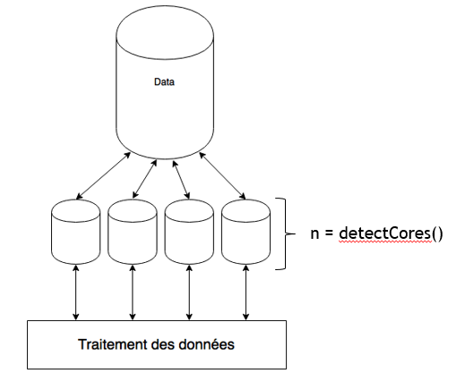

```r
    #Cluster
    ta <- Sys.time()
    cl <- makeCluster(detectCores())
    clusterEvalQ(cl,library(bit64))
    clusterEvalQ(cl,library(data.table))
    clusterEvalQ(cl,library(proj4))
    clusterEvalQ(cl,library(rgdal))
    print("Temps d'execution ")
    print(Sys.time() - ta)
```

# Projection des donnees GPS en coordonnees X Y

Nous utilisons d’abord la fonction subSetDataTable, qui permet de renvoyer une liste de subset de notre data.table de donnees GPS, afin de pouvoir executer le traitement sur plusieurs coeurs simultanement.

```r
    #Fonction qui permet de substter des data.table afin de les preparer pour des traitements multi-Threads Renvoie une liste contenant morceau par morceau le maximum de data par Coeur Processeurs
    subSetDataTable <- function(dataTable){
        a <- dataTable[-1,]
        a <- rbind(a,dataTable[nrow(dataTable)])
        index <- cbind(dataTable,a)
        colnames(index)[1] = "V1"

        #Calcul de la longueur de chaque Thread
        lengthThread <- ceiling(length(index$V1)/(detectCores()))

        tempList <- list()
        #Subset et append des data.tables
        for (i in 1:(detectCores())) {
            tempList[[i]] <- subset(index, (V1 >= index[lengthThread*(i-1) +1]$V1) & (V1 < index[lengthThread*i+1]$V1))
        }

        tempList
    }
```

Ensuite, nous parallelisons le traitement de projection grace a la fonction parLapply de la lirairie parallel, qui a le meme fonctionnement que la fonction lapply, mais sur plusieurs coeurs.

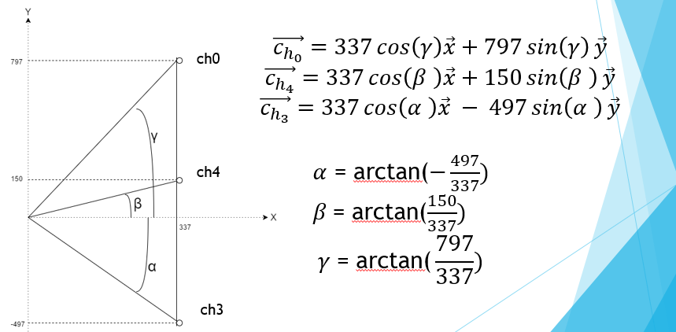

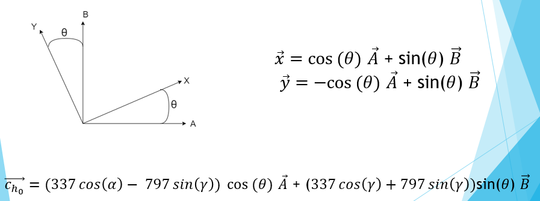

```r
    # Fonction permettant de projetter la latitude et la longitude en coordonnees GPS selon l'EPSG passe en parametre
    projection <- function(data,EPSG = 2154) {

        #Recuperation des donnees utiles du fichier GPS
        TS  <- data$V1
        lat <- data$V3
        lon <- data$V4

        # Creation du dataframe contenant les correspondances entre les codes EPSG et les parametre de projection
        EPSGPro4jMatching <- make_EPSG()
        # On remove les NAs
        EPSGPro4jMatching <- EPSGPro4jMatching[complete.cases(EPSGPro4jMatching),]
        # On regarde dans ce data frame a quelle ligne correspond le code epsg passe en parametre de fonction
        ligneParametreProjectionMatch <- match(EPSG, EPSGPro4jMatching$code)

        #On recupere le parametre de proj4 correspondant au code epsg passe en parmaetre
        paramProj4EFonctionEPSG <- as.character(EPSGPro4jMatching[ligneParametreProjectionMatch,3])

        # On projette les points GPS en coordonees selon le epsg passe en parametre
        conv <- proj4::project(xy = list(lon, lat),
                               proj = paramProj4EFonctionEPSG,
                               inverse = FALSE,
                               degrees = TRUE,
                               silent = FALSE,
                               ellps.default="sphere")
        #Conversion en Data Table
        dtConv <- as.data.table(conv)

        XLambert <- dtConv$x
        YLambert <- dtConv$y

        # Definition du positionnement des capteurs

        #### Definition des constantes de position des capteurs ####
        alpha <- atan(-497/337)
        beta <- atan(150/337)
        gamma <- atan(797/337)

        # Pour les premiers points de chaque capteur, on definit son orientation par rapport a la deuxieme valeur
        ##### Definition de l'orientation #####
        teta <- atan((XLambert[2]-XLambert[1])/(YLambert[2]-YLambert[1]))
        ##### Capteur 0 #####
        XLambertCapt0 <- XLambert[1]+(0.337*cos(gamma)-0.797*sin(gamma))*cos(teta)
        YLambertCapt0 <- YLambert[1]+(0.337*cos(gamma)+0.797*sin(gamma))*sin(teta)
        ##### Capteur 3 #####
        XLambertCapt3 <- XLambert[1]+(0.337*cos(beta)-0.15*sin(beta))*cos(teta)
        YLambertCapt3 <- YLambert[1]+(0.337*cos(beta)+0.15*sin(beta))*sin(teta)
        ##### Capteur 4 #####
        XLambertCapt4 <- XLambert[1]+(0.337*cos(alpha)+0.497*sin(alpha))*cos(teta)
        YLambertCapt4 <- YLambert[1]+(0.337*cos(alpha)-0.497*sin(alpha))*sin(teta)
        #### Distance par rapport a la valeur suivante #####
        DistancePoints <- sqrt((XLambert[2]-XLambert[1])^2+(YLambert[2]-YLambert[1])^2)

        # Boucle pour les points de 2 a n
        for(i in 2:(length(XLambert)-1)) {

            ##### Definition de l'orientation #####
            teta <- atan((XLambert[i]-XLambert[i-1])/(YLambert[i]-YLambert[i-1]))
            ##### Capteur 0 #####
            XLambertCapt0 <- c(XLambertCapt0, XLambert[i]+(0.337*cos(gamma)-0.797*sin(gamma))*cos(teta))
            YLambertCapt0 <- c(YLambertCapt0, YLambert[i]+(0.337*cos(gamma)+0.797*sin(gamma))*sin(teta))
            ##### Capteur 3 #####
            XLambertCapt3 <- c(XLambertCapt3, XLambert[i]+(0.337*cos(beta)-0.15*sin(beta))*cos(teta))
            YLambertCapt3 <- c(YLambertCapt3, YLambert[i]+(0.337*cos(beta)+0.15*sin(beta))*sin(teta))
            ##### Capteur 4 #####
            XLambertCapt4 <- c(XLambertCapt4, XLambert[i]+(0.337*cos(alpha)+0.497*sin(alpha))*cos(teta))
            YLambertCapt4 <- c(YLambertCapt4, YLambert[i]+(0.337*cos(alpha)-0.497*sin(alpha))*sin(teta))
            #### Distance par rapport a la valeur suivante #####
            DistancePoints <- c(DistancePoints, sqrt((XLambert[i+1]-XLambert[i])^2+(YLambert[i+1]-YLambert[i])^2))
        }

        # Pour les derniers points de chaque capteur, on definit son orientation par rapport a la deuxieme valeur
        ##### Definition de l'orientation #####
        teta <- atan((XLambert[length(XLambert)]-XLambert[length(XLambert)-1])/(YLambert[length(XLambert)]-YLambert[length(XLambert)-1]))

        ##### Capteur 0 #####
        XLambertCapt0 <- c(XLambertCapt0, XLambert[length(XLambert)]+(0.337*cos(gamma)-0.797*sin(gamma))*cos(teta))
        YLambertCapt0 <- c(YLambertCapt0, YLambert[length(XLambert)]+(0.337*cos(gamma)+0.797*sin(gamma))*sin(teta))
        ##### Capteur 3 #####
        XLambertCapt3 <- c(XLambertCapt3, XLambert[length(XLambert)]+(0.337*cos(beta)-0.15*sin(beta))*cos(teta))
        YLambertCapt3 <- c(YLambertCapt3, YLambert[length(XLambert)]+(0.337*cos(beta)+0.15*sin(beta))*sin(teta))
        ##### Capteur 4 #####
        XLambertCapt4 <- c(XLambertCapt4, XLambert[length(XLambert)]+(0.337*cos(alpha)+0.497*sin(alpha))*cos(teta))
        YLambertCapt4 <- c(YLambertCapt4, YLambert[length(XLambert)]+(0.337*cos(alpha)-0.497*sin(alpha))*sin(teta))
        #### Distance par rapport a la valeur precedente #####
        DistancePoints <- c(DistancePoints, sqrt((XLambert[length(XLambert)]-XLambert[length(XLambert)-1])^2+(YLambert[length(XLambert)]-YLambert[length(XLambert)-1])^2))

        #Formatage du resultat
        result <- data.table(TS)
        result <- cbind(result,XLambertCapt0,
                        YLambertCapt0,
                        XLambertCapt3,
                        YLambertCapt3,
                        XLambertCapt4,
                        YLambertCapt4,
                        DistancePoints)
    }
```

Code appelant ces fonctions.

```r
    #Projection des coordonnees GPS en positions [X:Y]
    taa <- Sys.time()
    listGps <- subSetDataTable(gps)
    projectedGps <- parLapply(cl,listGps,projection,2154)
    projectedGps <- rbindlist(projectedGps)
```

```
## [1] "Temps d'execution"
```

```
## Time difference of 3.309484 secs
```

# Generation des pseudo-timestamps et lissage des donnees

La fonction pseudoTimestamp permet de generer les pseudo-timestamps et de lisser les valeurs en faisant des moyennes sur 3 donnees

```r
    #Fonction qui parcours et applique en parallele les pseudo timestamps aux fichiers de donnees
    pseudoTimestamp <- function(lux){

        a <- lux
        a <- a[-1,]
        a <- rbind(a,data.frame(a[length(a$V1)]))
        index <- cbind(lux,a)
        colnames(index) <- c("T1","a","b","CAPT","T2","c","d","CAPT")

        #Generation du pseudoTimestamp
        TempDtPseudoTimestamp <- list()

        TempDtPseudoTimestamp[[1]] <- data.table(lux$V1)
        TempDtPseudoTimestamp[[2]] <- data.table(as.integer64((index$T1 + index$T2)/2))

        #Agregation des timestamps + pseudoTimestamps
        dtPseudoTimestamp <- data.table()
        dtPseudoTimestamp <- rbindlist(TempDtPseudoTimestamp)

        #Lissage des valeurs
        lissageValue <- list()
        parite <- c(0:(length(index$a)-1))*2+1
        lissageValueEven <- data.table((index$a + index$b + index$c)/3)
        lissageValue[[2]] <- cbind(lissageValueEven,parite)

        parite <- c(0:(length(index$a)-1))*2
        lissageValueOdd <- data.table((index$b + index$c + index$d)/3)
        lissageValue[[1]] <- cbind(lissageValueOdd,parite)

        lissage <- rbindlist(lissageValue)
        lissage <- cbind(dtPseudoTimestamp,lissage)
        lissage <- lissage[order(V1),]
        lissage$parite <- NULL
        colnames(lissage) <- c("TS","V")

        lissage
    }
```

Code appelant cette fonction.

```r
    #Generation des pseudoTimeStamps & lissage des moyennes
    tc <- Sys.time()
    tempPseudoTimeStampDT <- parLapply(cl,lux,pseudoTimestamp)
    for (i in 1:length(tempPseudoTimeStampDT)) {
            tempPseudoTimeStampDT[[i]][, CAPT := i]
    }
```

```
## [1] "Temps d'execution"
```

```
## Time difference of 3.198599 secs
```

# Calibration des luxmetres et conversion des volts en lux

Afin d’effctuer la calibration des luxmetre, nous faisons une moyenne de la valeur des capteurs pendant la premiere minute de releves.

```r
    ##Fonction qui permet de calculer Uo dans un data.table de capteur
    ##Pour cela, on calcule la moyenne des valeurs pendant la premiere minute
    convertLux <- function (captData,lMax,uMax) {
        ##On considere que une minute correspond a un ecart de 60 000 000 en TS
        setkeyv(captData, c("V1"))

        #On repere le premier timeStamp du fichier
        TS1 <- captData[[1,1]]

        #On ajoute une minute ? ce timeStamp
        TS2 <- TS1 + 60000000

        #On subset la data.table pour obtenir la moyenne des valeurs de capteur pendant
        #la premiere minute
        min <- 1
        max <- captData[J(TS2), roll=Inf, which = TRUE, mult = "last", rollends = TRUE]

        temp <- captData[min:max]

        #On obtient notre valeur de calibration
        u0 <- mean(temp$V2)
        a <- lMax/(uMax - u0)
        b <- -a*u0
        retour <- data.frame("u0" = u0,"a" = a,"b" = b)
        retour
    }
```

Code appelant cette fonction.

```r
    #Definition des constantes pour la calibration des luxmetres
    tb <- Sys.time()
    droite <- parLapply(cl,lux,convertLux,lMax = 3000,uMax = 3.3)
```

Nous utilisons ensuite les parametres retournes par la fonction convertLux pour etablir une loi lineaire et ainsi convertir les volts retournes par les capteurs en lux.

```r
    #Conversion Volts en Lux
    for (i in 1:length(tempPseudoTimeStampDT)) {
        tempPseudoTimeStampDT[[i]] <- cbind(tempPseudoTimeStampDT[[i]],data.frame("LUX" = droite[[i]]$a*tempPseudoTimeStampDT[[i]]$V + droite[[i]]$b))
    }
```

```
## [1] "Temps d'execution"
```

```
## Time difference of 1.187557 secs
```

Afin d’optimiser la recherche dans le data.table de valeurs de capteurs, nous definissons des keys de colonnes.

```r
    #Capteurs
    pseudoTimeStampDT <- rbindlist(tempPseudoTimeStampDT)
    keycols <- c("TS", "CAPT")
    pseudoTimeStampDT <- setkeyv(pseudoTimeStampDT, keycols)
```

# Agregation des donnees

Afin d’agreger les donnes, nous faisons appel, avec la fonction parLaplly, a la fonction loop. Celle ci prend en parametre les fichiers de donnees GPS et des luxmetres. Nous parcourons d’abord le fichier gps en recuperant deux timestamps consecutifs, nous repartissons ensuite les points des capteurs dont les valeurs sont incluses entre ces deux timestamps entre les points GPS afin d’obtenir une repartition spatiale plus homogene. Nous creons ensuite un fichier par coeur de processeur dans lequel est stoquee la position du point et sa valeur en lux.

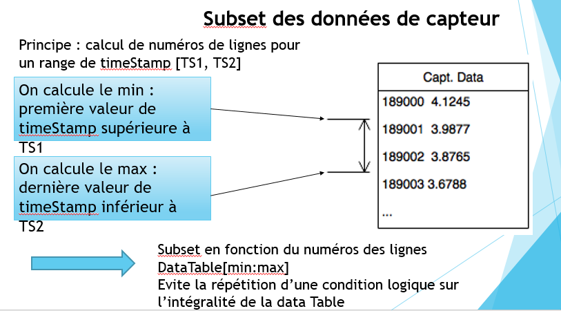

```r
    #Fonction de loop principale
    loop <- function(gps,lux){

        ##Definition de cette fonction dans la loop
        #Retourne une matrice contenant les points positionn?s sur une droite reliant deux points avec la valeur luxmetre correspondante
        getDroite <- function(x1,x2,y1,y2,subsetCapt){
            if (nrow(subsetCapt) >= 1) {

                #Calcul du nombre de points
                nbPoints <- nrow(subsetCapt)

                # Calcul de l'ecart des points sur l'axe des abscisses et des ordonn?es
                ecartPointsX <- (x2 - x1)/nbPoints
                ecartPointsY <- (y2 - y1)/nbPoints

                i <- c(0:(nbPoints-1))

                xTemp <- i*ecartPointsX + x1
                yTemp <- i*ecartPointsY + y1

                res <- data.table (xTemp,yTemp,subsetCapt$LUX)
            }
        }

        #Cherche dans chaque data.table les valeurs de capteurs
        #correspondant au range passe en parametre
        lookRange <- function(gps,lux){

            TS1 <- gps[1]
            TS2 <- gps[9]

            class(TS1) <- "integer64"
            class(TS2) <- "integer64"

            min <- lux[J(TS1), roll=-Inf, which = TRUE, mult = "first", rollends = TRUE]
            max <- lux[J(TS2), roll=Inf, which = TRUE, mult = "last", rollends = TRUE]

            if(min != 1 && max!= 1){

                temp <- lux[min:max]

                #Subset des valeurs de capteurs
                droiteCaptList <- list()
                for (i in 1:3) {
                    #Calcul des points interm?diaires en leur associant leur valeur de luxmetre
                    droiteCaptList[[i]] <- getDroite(gps[(i*2)],gps[(8+(i*2))],gps[((i*2)+1)],gps[(8+(i*2+1))],subset(temp, CAPT == i))
                }

                finalToWrite <- rbindlist(droiteCaptList)
            }
        }

        data <- apply(gps,MARGIN = 1,lookRange,lux)

        i <- 0
        while (file.exists(paste("../data/output_", i,".csv", sep = "")) && i < 100) {
            i <- i + 1
        }

        write.table(rbindlist(data),paste("../data/output_", i ,".csv",sep = ""), append = FALSE, quote = FALSE, sep = ";",row.names=FALSE)
    }
```

```
## [1] "Temps d'execution"
```

```
## Time difference of 1.528767 mins
```

# Creation du fichier final

Nous recuperons tous les fichiers intermediaires afin de les aggreger et de creer le fichier final.

```r
    #Enregistrement des donnees dans le fichier
    tf <- Sys.time()

    index <- createIndex()
    for (i in 2:length(index$output)) {
        file.append(index$output[1],index$output[i])
        file.remove(index$output[i])
    }
```

```
## [1] "Temps d'execution"
```

```
## Time difference of 2.906906 secs
```

```
## [1] "*********************************"
```

```
## [1] "Temps total d'execution du script"
```

```
## Time difference of 1.920069 mins
```